# VISUALIZE COVID-19

Tri Nguyen

7/2/2021

# 1.From epidemic to pandemic

In December 2019, COVID-19 coronavirus was first identified in the Wuhan region of China. By March 11, 2020, the World Health Organization (WHO) categorized the COVID-19 outbreak as a pandemic. A lot has happened in the months in between with major outbreaks in Iran, South Korea, and Italy.

We know that COVID-19 spreads through respiratory droplets, such as through coughing, sneezing, or speaking. But, how quickly did the virus spread across the globe? And, can we see any effect from country-wide policies, like shutdowns and quarantines?

Fortunately, organizations around the world have been collecting data so that governments can monitor and learn from this pandemic. Notably, the Johns Hopkins University Center for Systems Science and Engineering created a publicly available data repository to consolidate this data from sources like the WHO, the Centers for Disease Control and Prevention (CDC), and the Ministry of Health from multiple countries.

# 2. Load the library needed for analysis

```r
library(coronavirus)
glimpse(coronavirus)
```

```
## Rows: 399,996
## Columns: 7
## $ date     <date> 2020-01-22, 2020-01-22, 2020-01-22, 2020-01-22, 2020-01-22, ~
## $ province <chr> "", "", "", "", "", "", "", "", "Australian Capital Territory~
## $ country  <chr> "Afghanistan", "Albania", "Algeria", "Andorra", "Angola", "An~
## $ lat      <dbl> 33.93911, 41.15330, 28.03390, 42.50630, -11.20270, 17.06080, ~
## $ long     <dbl> 67.709953, 20.168300, 1.659600, 1.521800, 17.873900, -61.7964~
## $ type     <chr> "confirmed", "confirmed", "confirmed", "confirmed", "confirme~
## $ cases    <dbl> 0, 0, 0, 0, 0, 0, 0, 0, 0, 0, 0, 0, 0, 0, 0, 0, 0, 0, 0, 0, 0~
```

# 3. Confirmed cases throughout the world

Filter the table, only choose the data row whose type is confirmed case

```r
cfm <- coronavirus %>%
  filter(type == 'confirmed')
```

Add columns that show total case by date and cumlative number of cases accross date

```r
total_cfm <- cfm %>%
group_by(date) %>%
summarise(total_cases = sum(cases)) %>%
mutate(cum_cases = cumsum(total_cases))
```

Draw a line plot of cumulative cases vs. date

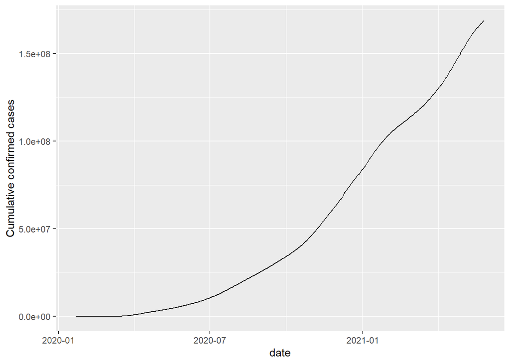

```r
ggplot(total_cfm, aes(y=cum_cases, x=date)) +
  geom_line() +
  ylab('Cumulative confirmed cases')
```

# 4. Virus accross the countries

Create frame that contain 3 types of cases for each country

```r
#world total confirmed cases by date
cfm_cases <- coronavirus %>%
  filter(type == 'confirmed') %>%
group_by(country) %>%
summarise(confirmed = sum(cases))
```

Top 10 countries with the highest number of affected cases:

```r
cfm_top10 <- cfm_cases %>%
top_n(10)
cfm_top10[order(-cfm_top10$confirmed),]
```

```
## # A tibble: 10 x 2
##    country        confirmed
##    <chr>              <dbl>
##  1 US              33217995
##  2 India           27555457
##  3 Brazil          16342162
##  4 France           5697076
##  5 Turkey           5220549
##  6 Russia           4977332
##  7 United Kingdom   4489552
##  8 Italy            4205970
##  9 Germany          3673990
## 10 Argentina        3663215
```

```r
#world total death cases by date
d_cases <- coronavirus %>%
  filter(type == 'death') %>%
  group_by(country) %>%
summarise(death = sum(cases))

# Countries with highest number of death cases
d_cases[order(-d_cases$death),]
```

```
## # A tibble: 193 x 2
##    country         death
##    <chr>           <dbl>
##  1 US             593288
##  2 Brazil         456674
##  3 India          318895
##  4 Mexico         222661
##  5 United Kingdom 128020
##  6 Italy          125793
##  7 Russia         117990
##  8 France         109327
##  9 Germany         88192
## 10 Colombia        86693
## # ... with 183 more rows
```

```r
#world total recovered cases by date
r_cases <- coronavirus %>%
  filter(type == 'recovered') %>%
  group_by(country) %>%
summarise(recovered = sum(cases))
```

Join 3 into 1 single frame

```r
type_country = cfm_cases %>%
  full_join(r_cases,by="country") %>%
  full_join(d_cases,by="country")
type_country
```

```
## # A tibble: 193 x 4
##    country             confirmed recovered death
##    <chr>                   <dbl>     <dbl> <dbl>
##  1 Afghanistan             68366     56962  2869
##  2 Albania                132264    129042  2447
##  3 Algeria                127926     89040  3448
##  4 Andorra                 13682     13405   127
##  5 Angola                  33607     27529   745
##  6 Antigua and Barbuda      1258      1200    42
##  7 Argentina             3663215   3219474 76135
##  8 Armenia                222409    212265  4416
##  9 Australia               30074     23571   910
## 10 Austria                643168    626259 10573
## # ... with 183 more rows
```

```r
rrate_country <- type_country %>%
  mutate(r_rate = round((recovered/confirmed),4))

rrate_country
```

```
## # A tibble: 193 x 5
##    country             confirmed recovered death r_rate
##    <chr>                   <dbl>     <dbl> <dbl>  <dbl>
##  1 Afghanistan             68366     56962  2869  0.833
##  2 Albania                132264    129042  2447  0.976
##  3 Algeria                127926     89040  3448  0.696
##  4 Andorra                 13682     13405   127  0.980
##  5 Angola                  33607     27529   745  0.819
##  6 Antigua and Barbuda      1258      1200    42  0.954
##  7 Argentina             3663215   3219474 76135  0.879
##  8 Armenia                222409    212265  4416  0.954
##  9 Australia               30074     23571   910  0.784
## 10 Austria                643168    626259 10573  0.974
## # ... with 183 more rows
```

Countries with highest recoverd rate:

```r
rrate_country[order(-rrate_country$r_rate),]
```

```
## # A tibble: 193 x 5
##    country          confirmed recovered death r_rate
##    <chr>                <dbl>     <dbl> <dbl>  <dbl>
##  1 Holy See                27        27     0  1
##  2 Marshall Islands         4         4     0  1
##  3 Micronesia               1         1     0  1
##  4 Samoa                    3         3     0  1
##  5 Solomon Islands         20        20     0  1
##  6 Grenada                161       160     1  0.994
##  7 Tajikistan           13308     13218    90  0.993
##  8 Israel              839420    832490  6406  0.992
##  9 Singapore            61940     61372    32  0.991
## 10 Iceland               6555      6476    29  0.988
## # ... with 183 more rows
```

# 5.Vietnam Coronavirus Status

## Fetching Vietnam Data Corona Virus from ‘coronavirus’ library

Filter the data

```r
vietnam_corona <- coronavirus %>%
  select(-c("province","lat","long")) %>%
  filter(country == "Vietnam")

vietnam_corona <- vietnam_corona %>%
      group_by(date, type) %>%
      summarise(tt_case=sum(cases))
vietnam_corona <- vietnam_corona %>%
     group_by(type) %>%
     mutate(cum_cases = cumsum(tt_case))
```

```r
vn_cases <- vietnam_corona %>%
  group_by(date) %>%
  filter(type == 'confirmed')
vn_cases
```

```
## # A tibble: 492 x 4
## # Groups:   date [492]
##    date       type      tt_case cum_cases
##    <date>     <chr>       <dbl>     <dbl>
##  1 2020-01-22 confirmed       0         0
##  2 2020-01-23 confirmed       2         2
##  3 2020-01-24 confirmed       0         2
##  4 2020-01-25 confirmed       0         2
##  5 2020-01-26 confirmed       0         2
##  6 2020-01-27 confirmed       0         2
##  7 2020-01-28 confirmed       0         2
##  8 2020-01-29 confirmed       0         2
##  9 2020-01-30 confirmed       0         2
## 10 2020-01-31 confirmed       0         2
## # ... with 482 more rows
```

Draw a line plot to visualize the Vietnamese confirmed cases and a trend line to measure how fast the number of cases is growing

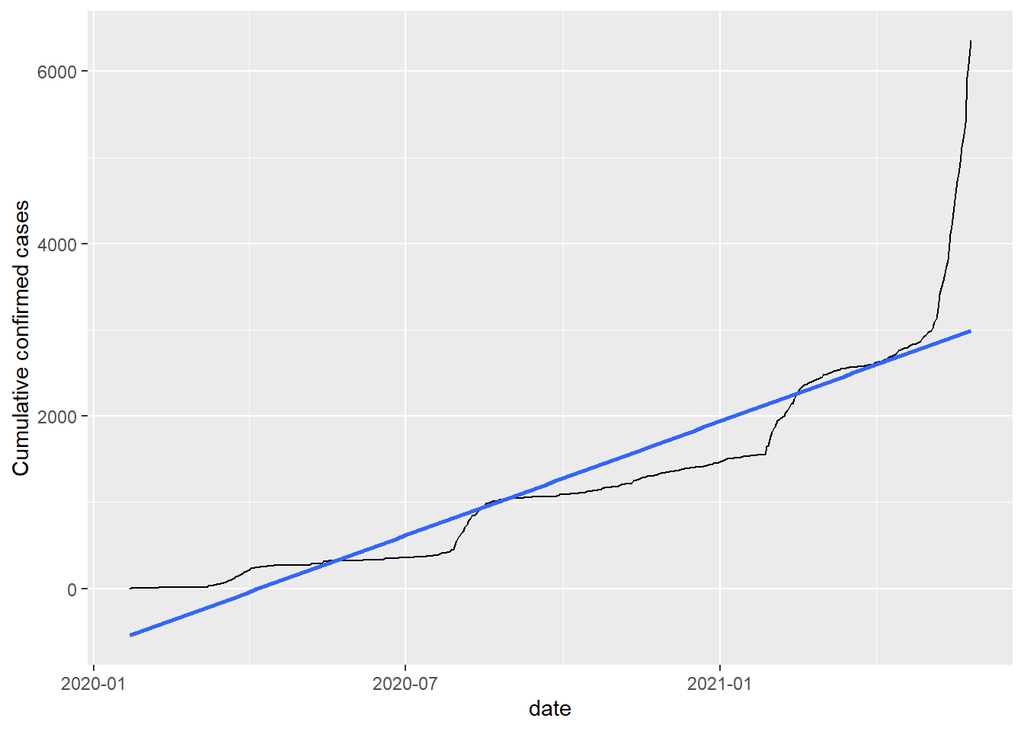

```r
ggplot(vn_cases, aes(x=date, y=cum_cases)) +
  geom_line() +
  geom_smooth(method='lm', se=FALSE) +
  ylab("Cumulative confirmed cases")
```

Plot show confirmed, death and recovered cases in Vietnam

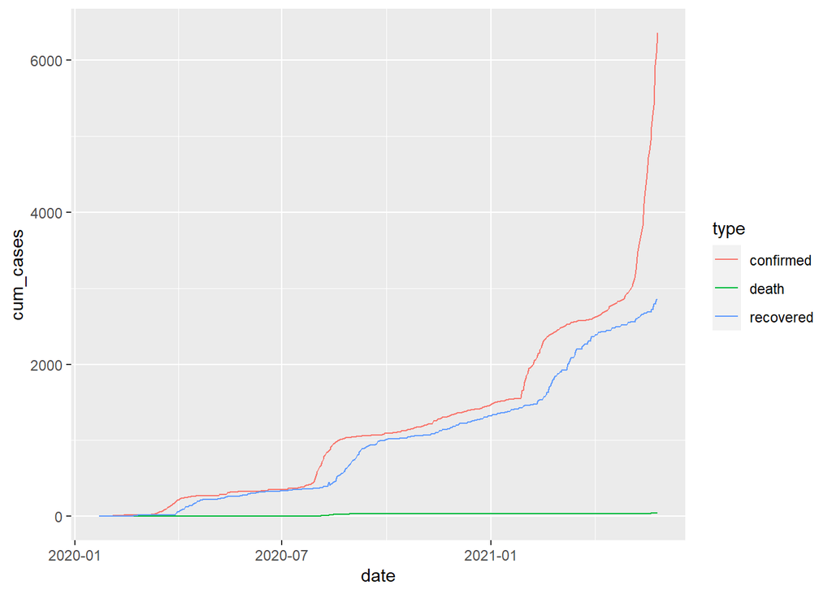

```r
vietnam_type <- ggplot(vietnam_corona) + geom_line(aes(x=date,y=cum_cases,group=type,color=type))
vietnam_type
```

Add some important milestones give us a clearer understanding how Vietnamese virus trend has shifted during these period The milestone was refenrenced from wikipedia: COVID-19 pandemic in Vietnam (https://en.wikipedia.org/wiki/COVID-19_pandemic_in_Vietnam)

```r
#create a tibble for Vietnamese corona virus event
vietnam_events <- tribble(
  ~ date, ~ event,
  "2020-01-23", "First infected case in Vietnam",
  "2020-07-25", "Da Nang Outbreak",
  "2021-01-28", "Hai Duong outbreak",
  "2021-04-27", "Ho Chi Minh outbreak") %>%
  mutate(date = as.Date(date))
vietnam_events
```

```
## # A tibble: 4 x 2
##   date       event
##   <date>     <chr>
## 1 2020-01-23 First infected case in Vietnam
## 2 2020-07-25 Da Nang Outbreak
## 3 2021-01-28 Hai Duong outbreak
## 4 2021-04-27 Ho Chi Minh outbreak
```

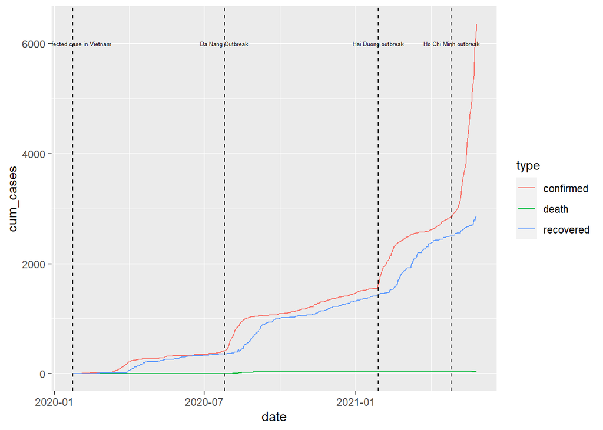

```r
# Using who_events, add vertical dashed lines with an xintercept at date
# and text at date, labeled by event, and at 100000 on the y-axis
vietnam_type +
  geom_vline(data=vietnam_events, aes(xintercept=date), linetype="dashed") +
  geom_text(data=vietnam_events,aes(x=date, label=event), y=6000, size=1.7)
```

# 6.Vietnam compare to Asean Countries

*Retrieved the data from “coronavirus” library, filter Asean countries, comprises of: -Brunei -Malaysia -East Timor -Indonesia -Philipines -Singapore -Cambodia -Laos -Myanmar -Malaysia -Thailand -Vietnam

```r
aseancountries <-c("Brunei","Cambodia","Malaysia","Timor-Leste","Malaysia","Philippines","Singapore","Laos","Burma","Thailand","Vietnam","Indonesia")
asean <- coronavirus %>%
  filter(country %in% aseancountries)
str(asean)
```

```
## 'data.frame':    16236 obs. of  7 variables:
##  $ date    : Date, format: "2020-01-22" "2020-01-22" ...
##  $ province: chr  "" "" "" "" ...
##  $ country : chr  "Brunei" "Burma" "Cambodia" "Indonesia" ...
##  $ lat     : num  4.535 21.916 11.55 -0.789 19.856 ...
##  $ long    : num  115 96 105 114 102 ...
##  $ type    : chr  "confirmed" "confirmed" "confirmed" "confirmed" ...
##  $ cases   : num  0 0 0 0 0 0 0 0 4 0 ...
```

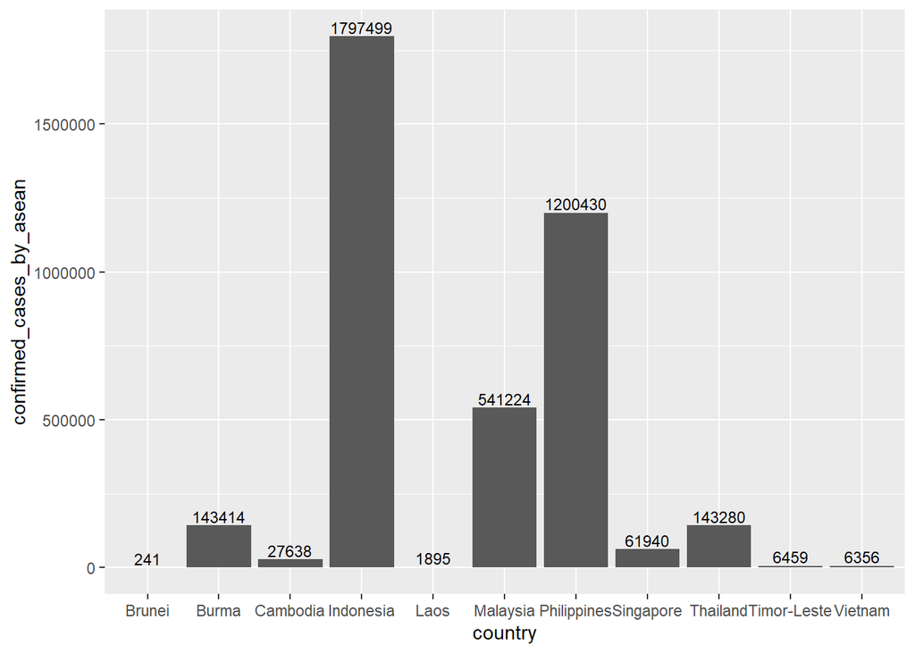

```r
asean %>%
  filter(type=="confirmed") %>%
group_by(country) %>%
summarise(confirmed_cases_by_asean = sum(cases)) %>%
ggplot(aes(x = country, y = confirmed_cases_by_asean)) +
geom_col(position = "dodge") +
geom_text(aes(label=confirmed_cases_by_asean), position=position_dodge(width=0.9), vjust=-0.25,size=3)
```

```r
#world total death cases by date
death_asean <- asean %>%
  filter(type == 'death') %>%
  group_by(country) %>%
summarise(d_asean_cases = sum(cases))
```

```r
#world total confirmed cases by date
confirmed_asean <- asean %>%
  filter(type == 'confirmed') %>%
  group_by(country) %>%
summarise(c_asean_cases = sum(cases))
```

```r
#world total confirmed cases by date
recovered_asean <- asean %>%
  filter(type == 'recovered') %>%
  group_by(country) %>%
summarise(r_asean_cases = sum(cases))
```

```r
case_type_asean =  confirmed_asean %>%
  full_join(recovered_asean,by="country") %>%
  full_join(death_asean,by="country")
case_type_asean
```

```
## # A tibble: 11 x 4
##    country     c_asean_cases r_asean_cases d_asean_cases
##    <chr>               <dbl>         <dbl>         <dbl>
##  1 Brunei                241           228             3
##  2 Burma              143414        132269          3216
##  3 Cambodia            27638         20398           194
##  4 Indonesia         1797499       1649187         49907
##  5 Laos                 1895          1281             2
##  6 Malaysia           541224        469325          2491
##  7 Philippines       1200430       1131942         20379
##  8 Singapore           61940         61372            32
##  9 Thailand           143280         26873           920
## 10 Timor-Leste          6459          3717            15
## 11 Vietnam              6356          2853            46
```

```r
 asean_v1 <- case_type_asean %>%
  group_by(country) %>%
  mutate(d_rate = d_asean_cases/c_asean_cases ) %>%
  mutate(r_rate = r_asean_cases/c_asean_cases )
asean_v1
```

```
## # A tibble: 11 x 6
## # Groups:   country [11]
##    country     c_asean_cases r_asean_cases d_asean_cases   d_rate r_rate
##    <chr>               <dbl>         <dbl>         <dbl>    <dbl>  <dbl>
##  1 Brunei                241           228             3 0.0124    0.946
##  2 Burma              143414        132269          3216 0.0224    0.922
##  3 Cambodia            27638         20398           194 0.00702   0.738
##  4 Indonesia         1797499       1649187         49907 0.0278    0.917
##  5 Laos                 1895          1281             2 0.00106   0.676
##  6 Malaysia           541224        469325          2491 0.00460   0.867
##  7 Philippines       1200430       1131942         20379 0.0170    0.943
##  8 Singapore           61940         61372            32 0.000517  0.991
##  9 Thailand           143280         26873           920 0.00642   0.188
## 10 Timor-Leste          6459          3717            15 0.00232   0.575
## 11 Vietnam              6356          2853            46 0.00724   0.449
```

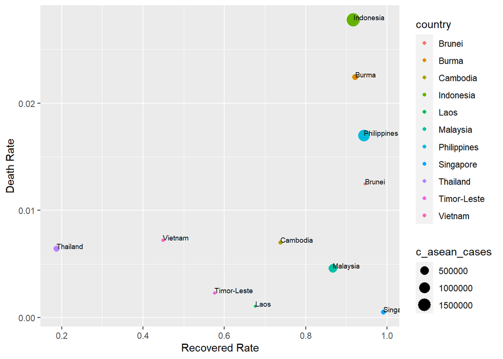

```r
ggplot(asean_v1,aes(x=r_rate,y=d_rate)) + geom_point(aes(size = c_asean_cases,color = country)) +geom_text(aes(label=country),hjust=0, vjust=0, size = 2.5) +ylab("Death Rate")+xlab("Recovered Rate")
```